# Ford GoBike Final slides

## Project - Ford GoBike 2018 Analysis

### Project Overview

**The purpose of this project is to analyze a compilation of Ford Go-Bike's system data. Ford Go-Bike is a bike sharing service located in San Francisco, allowing easy access for transportation around the Bay Area. The project will focus on exploratory and explanatory data analysis by creating visualizations to understand the relationships between the key features and metrics collected by Ford Go-Bike.**

### Data Overview

**Ford Go-Bike offers public-use of their system data dating back to 2017. The following analysis covers all of the data collected over the 2018 year. 12 csv files (January-December) were downnloaded and concatenated into one main dataframe.**

**The following 15 features are collected by Ford Go-Bike: Trip Duration, Start Time and Date, End Time and Date, Start Station ID, Start Station Name, Start Station Latitude, Start Station Longitude, End Station ID, End Station Name, End Station Latitude, End Station Longitude, Bike ID, User Type, Member Year of Birth, and Member Gender.**

### Data Wrangling

**The 2018 dataset consists of over 1.8 million rows.**

### Explanatory Data Analysis

**The significance of the null data is assessed.**

**First, the Bike ID's are examined. The bar chart shows null values are highly concentrated in the 4100-4400 region.**

**The plots could suggest a product failure i.e. a bad manufacturing batch since the data is concentrated, a possible software glitch, or maybe an issue with the geo-tracking system. Whatever the case, since null values don't define any critical feature, we'll leave these rows in.**

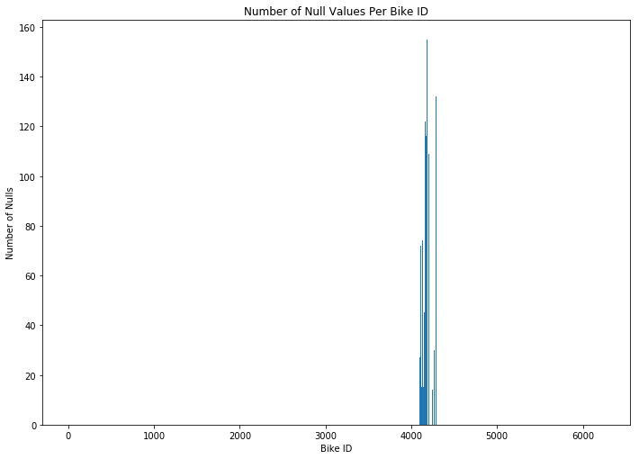

```python
# Number of null values for every Bike ID
bike = df.groupby('bike_id')['start_station_id'].apply(lambda x: x.isnull().sum()).sort_values(ascending=False)

# Examine relationship between null values and Bike ID
base_color = sb.color_palette()[0]
plt.figure(figsize=[11.69, 8.27])
plt.bar(x = bike.index, height=bike.values, color = base_color);
plt.xlabel('Bike ID')
plt.ylabel('Number of Nulls')
plt.title('Number of Null Values Per Bike ID');
```

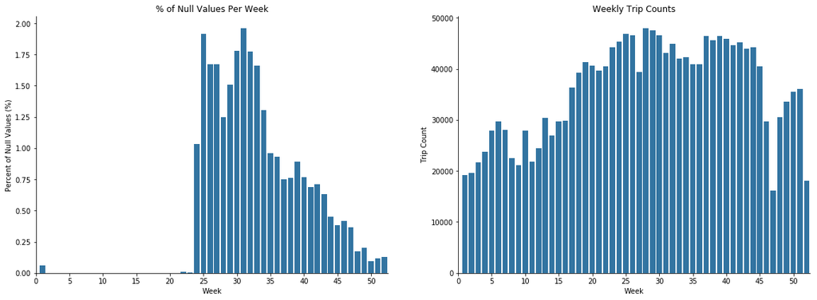

```python
# Percentage of null values per week
null_perc = (df.groupby('Week').apply(lambda x: x.isnull().sum()).start_station_id) \
/(df['Week'].value_counts().sort_index())

plt.figure(figsize = [19.6, 6.7])
labels = [0,5,10,15,20,25,30,35,40,45,50]
xticks = np.arange(np.arange(df['Week'].min())-1, max(df['Week']), 5)

# Plot of Percentage of Nulls by Week
plt.subplot(1, 2, 1)
ax1 = sb.barplot(x = null_perc.index.values, y = null_perc.values * 100, color = base_color);
plt.xticks(xticks,labels)
plt.title('% of Null Values Per Week')
ax1.set(xlabel='Week', ylabel='Percent of Null Values (%)')
ax1.spines['right'].set_visible(False)
ax1.spines['top'].set_visible(False)

# Plot of Trip Counts by Week
plt.subplot(1, 2, 2)
ax2 = sb.countplot(x="Week", data=df, color = base_color)
plt.xticks(xticks,labels)
plt.title('Weekly Trip Counts')
ax2.set(xlabel='Week', ylabel='Trip Count')
ax2.spines['right'].set_visible(False)
ax2.spines['top'].set_visible(False);
```

#### Univariate Relationships

**Binning reveals the data is highly skewed to the right. A log transform can be used to reduce the skeweness of the data.**

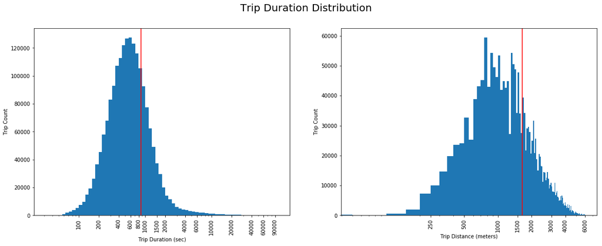

```python
# Histograms of duration and distance of trips - log transformation of the x-scale
np.log10(df['duration_sec'].describe());
df['distance_m'].describe()

bin_size = 0.05
bins = 10**np.arange(1.5, 5+bin_size, bin_size)
ticks = [100, 200, 400, 600, 800, 1000, 1500, 2000, 4000, 6000, 10000, 20000, 40000, 60000, 90000]
ticks_distance = [250, 500, 1000, 1500, 2000, 3000, 4000, 6000]
labels = ['{}'.format(val) for val in ticks]

plt.figure(figsize = [19.6, 6.7])
plt.subplot(1, 2, 1)
plt.hist(data = df, x = 'duration_sec', bins = bins)
plt.ylabel('Trip Count')
plt.xscale('log')
plt.xticks(ticks, labels, rotation = 'vertical')
plt.xlabel('Trip Duration (sec)')
plt.axvline(x=df.duration_sec.mean(), color='r') # Vertical Mean Line

plt.subplot(1, 2, 2)
bins1 = np.arange(0, 6000+50, 50)
plt.hist(data = df.query('0 < distance_m <= 10000'), x = 'distance_m', bins = bins1)
plt.xscale('log')
plt.xticks(ticks_distance, ticks_distance, rotation = 'vertical')
plt.ylabel('Trip Count')
plt.xlabel('Trip Distance (meters)')
plt.suptitle('Trip Duration Distribution', fontsize=20);
plt.axvline(x=df.query('0 < distance_m <= 10000')['distance_m'].mean(), color='r'); # Vertical Mean Line
```

**The start time distribution is explored below. The data was separated into hourly bins for simplicity. Peak times are at 8:00 AM and 5:00 PM (rush hour times).**

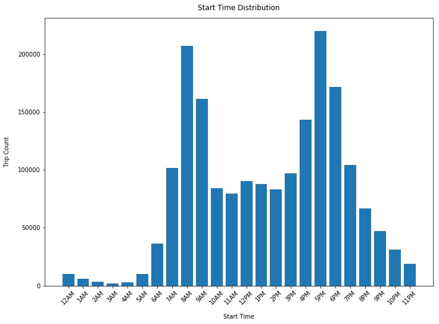

```python
df['start_time_hour'] = df['start_time'].dt.hour

time_labels = ['12AM','1AM','2AM','3AM','4AM','5AM','6AM','7AM','8AM','9AM','10AM','11AM','12PM',
              '1PM','2PM','3PM','4PM','5PM','6PM','7PM','8PM','9PM','10PM','11PM']

plt.figure(figsize=[11.69, 8.27])
time_xticks = np.arange(0, 24, 1)

plt.bar(x = df['start_time_hour'].value_counts().index, height = df['start_time_hour'].value_counts().values)
plt.title('Start Time Distribution', pad=13)
plt.xlabel('Start Time', labelpad=13)
plt.ylabel('Trip Count', labelpad=13)
plt.xticks(time_xticks,time_labels, rotation = 45);
```

**Age is queried for 2 reasons. Very few data points actually exist for user ages greater than 75. This removes noise from the plot. Also, some age's exist in the dataset that are likely unrealistic or incorrect. Chances are, senior citizens older than 120 or let alone 100 would not be using this service. Possible explanation could be the customer entered in the birth year incorrectly.**

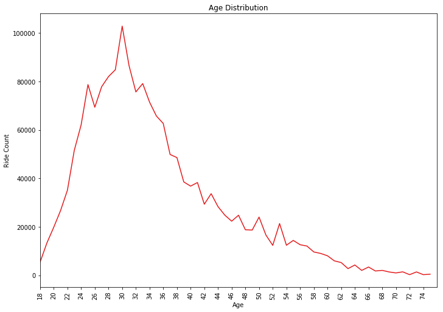

```python
# View 'Age' column stats to determine appropriate plot parameters
df['Age'].describe();

# Drop null values for analysis (No Effect on results), Filter Ages less than 75
Age_hist = df.dropna(axis=0, subset=['Age']).reset_index(drop=True)
Age_hist.Age = Age_hist.Age.astype(int)
Age_hist = Age_hist.query('Age <= 75')

# Line Plot
base_color1 = sb.color_palette('Set1')[0]
plt.figure(figsize=[11.69, 8.27])
labels1 = range(18,75,2)
xticks1 = np.arange(18, 76, 2)
ax3 = sb.lineplot(x= Age_hist['Age'].value_counts().index, y = Age_hist['Age'].value_counts().values, color = base_color1)
ax3.set(xlabel='Age', ylabel='Ride Count')
plt.xticks(xticks1,labels1, rotation = 'vertical')
plt.xlim((18,76))
plt.title('Age Distribution');
```

**Bivariate Relationships**

**First, we'll investigate how the Ford's Go-Bike membership program (bike share for all) relates to the duration of the ride. It's important to note that according to the fordgobike website, membership includes first 60 minutes of each trip. Rides longer than 60 minutes result in additional fees of 3 dollars for each additional 15 minutes or potential account suspension.**

**Second, we'll take a look at male/female distribution among user types to determine if one gender uses the Bike Share For All program more than the other.**

**We can see by the violin plot that 3.0% and 1.2% of Bike Share For All trips lasted over 45 min and 60 min, respectively, meaning some program member incurred either an extra fee or possible account suspension. Reducing the alotted time for a ride, to say 45 min, before a fee could be considered, atleast for A/B testing.**

```
Percentage of Bike Share For All rides that lasted more than 45 min (Green Line) = 3.0578741491360457
Percentage of Bike Share For All rides that lasted more than 60 min (Red Line) = 1.2270921243108388
```

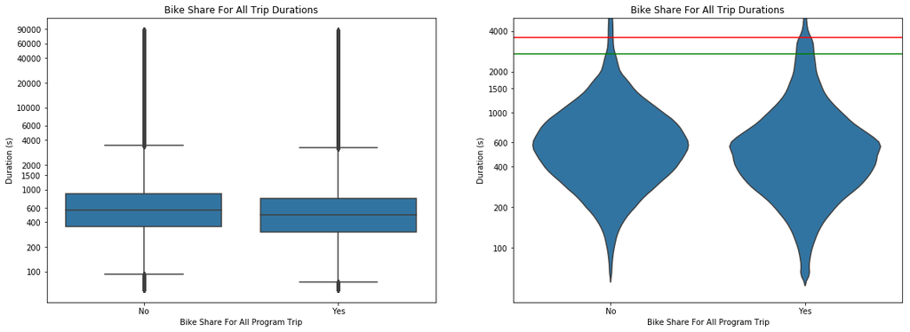

```python
# Duration vs Membership Program
plt.figure(figsize = [19.6, 6.7])
ticks = [100, 200, 400, 600, 1000, 1500, 2000, 4000, 6000, 10000, 20000, 40000, 60000, 90000]

# left plot: box plot of complete data
plt.subplot(1, 2, 1)
sb.boxplot(x = df['bike_share_for_all_trip'], y = df['duration_sec'].apply(log_trans), color = base_color)
plt.yticks(log_trans(ticks), ticks);
plt.xlabel('Bike Share For All Program Trip')
plt.ylabel('Duration (s)')
plt.title('Bike Share For All Trip Durations')

# right plot: violin plot filtering outliers from previous boxplot
plt.subplot(1, 2, 2)
ax5 = sb.violinplot(x = df['bike_share_for_all_trip'], y = df['duration_sec'].apply(log_trans), color = base_color,
                   inner = None)
plt.yticks(log_trans(ticks), ticks)
plt.ylim((1.6,3.7))
plt.xlabel('Bike Share For All Program Trip')
plt.ylabel('Duration (s)')
plt.title('Bike Share For All Trip Durations')

ax5.axhline(y=np.log10(3600), color='r') # Horizontal Line at 60 minutes
ax5.axhline(y=np.log10(2700), color='g'); # Horizontal Line at 45 minutes

# Calculate % of trips where Program Members ride for more than 45 min & 60 minutes
print("Percentage of Bike Share For All rides that lasted more than 45 min (Green Line) =",
      df.query("bike_share_for_all_trip == 'Yes' & duration_sec >=2700").shape[0]*100 /\
df.query("bike_share_for_all_trip == 'Yes'").shape[0])

print("Percentage of Bike Share For All rides that lasted more than 60 min (Red Line) =",
      df.query("bike_share_for_all_trip == 'Yes' & duration_sec >=3600").shape[0]*100 /\
df.query("bike_share_for_all_trip == 'Yes'").shape[0])
```

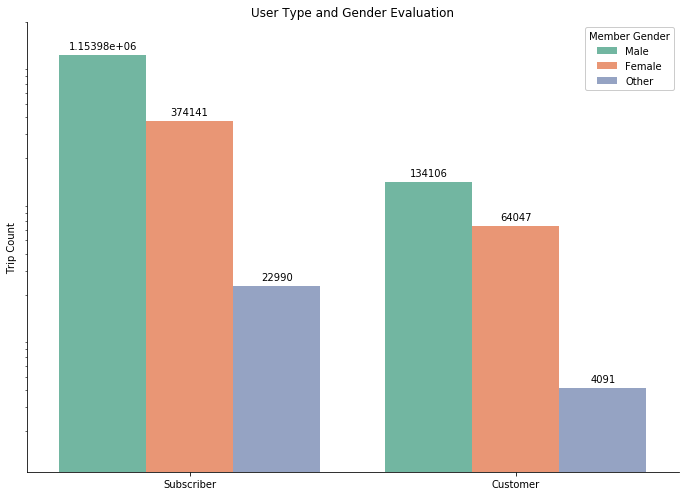

```python
# Log Transform performed on y-scale
gender = df.dropna(axis=0, subset=['member_gender']).reset_index(drop=True)
ticks2 = [1000, 5000, 10000, 50000, 100000, 250000, 500000, 750000, 2000000]

# Countplot
plt.figure(figsize=[11.69, 8.27])
ax5 = sb.countplot(data = gender, x = 'user_type', hue = 'member_gender', palette = 'Set2', alpha = 1)
ax5.legend(loc = 1, ncol = 1, framealpha = 1, title = 'Member Gender')
ax5.spines['right'].set_visible(False)
ax5.spines['top'].set_visible(False)

plt.yscale('log')
plt.yticks(ticks2, None)
ax5.yaxis.set_major_locator(plt.NullLocator())
plt.ylabel('Trip Count')
plt.xlabel(None)
plt.title('User Type and Gender Evaluation')
rcParams['axes.titlepad'] = 15

# Add values to bars
for p in ax5.patches[0:]:
    h = p.get_height()
    x = p.get_x()+p.get_width()/2.
    if h != 0:
        ax5.annotate("%g" % p.get_height(), xy=(x,h), xytext=(0,4),
                     textcoords="offset points", ha="center", va="bottom")
```

**Multivariate Relationship**

```
Number of Rides By Time of Day
 3PM-6PM     83472
6AM-9AM     75770
9AM-12PM    63909
6PM-9PM     57517
12PM-3PM    38297
9PM-12AM    10485
12AM-3AM     1380
3AM-6AM      1053
Name: session, dtype: int64
```

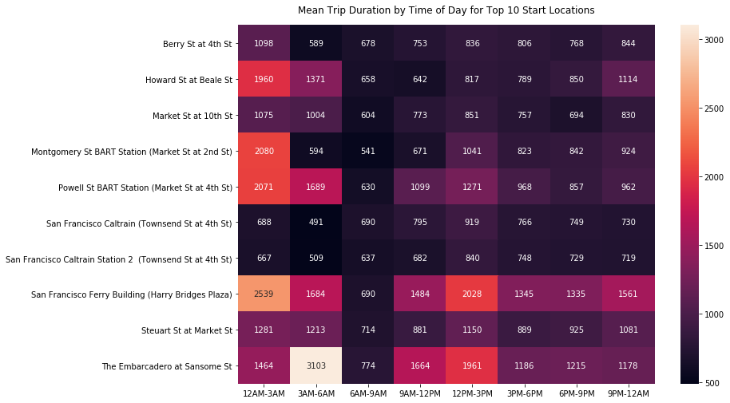

```python
# Create new column binning each start time to time of day
multiv = df.copy()
multiv = multiv.assign(session=pd.cut(multiv['start_time'].dt.hour, bins=8,
                                      labels=['12AM-3AM','3AM-6AM','6AM-9AM','9AM-12PM','12PM-3PM','3PM-6PM','6PM-9PM','9PM-12AM']))

# Filter dataframe based on top 10 list of start stations
top_10 = df['start_station_name'].value_counts().nlargest(10).index.tolist()
multiv = multiv[multiv['start_station_name'].isin(top_10)]

# Calculate Categorical Mean for each group
cat_means = multiv.groupby(['session', 'start_station_name']).mean()['duration_sec']
cat_means = cat_means.reset_index(name = 'mean_duration')
cat_means = cat_means.pivot(index = 'start_station_name', columns = 'session',
                            values = 'mean_duration')

# Plot Heatmap
plt.figure(figsize=[11.69, 8.27])
sb.heatmap(cat_means, annot = True, fmt = '.0f', cbar_kws = {'label' : ''})
plt.xlabel(None)
plt.ylabel(None)
plt.title('Mean Trip Duration by Time of Day for Top 10 Start Locations')
rcParams['axes.titlepad'] = 15;

print('Number of Rides By Time of Day \n', multiv.session.value_counts())
```

### Results & Discussion

**The analysis above is divided into the 3 sections: Univariate Relationships, Bivariate Relationships, and Multivariate Relationships.**

**Distance, trip duration, and age are investigated in the univariate relationship section. All 3 of these variables follow a log-normal distribution. Accounting for outliers, the mean duration traveled is roughly 800 s with most trips lasting 650 s. The mean distance traveled is approximately 1600 m with a majority of trips lasting anywhere between 700-1500 m. Most users who have used the Ford Go-Bike service are young adults (late 20's to early 30's) with a steady drop off beginning at 33 years old.**

**Next bivariate relationships between trip duration, trip type (Ford Go-Bikes Bike Share For All), membership, and user gender were examined. Bike Share For All trips are expected to level off at 60 min due to the fee for additional time over this time limit. This hypothesis is supported by the data as only 1.2% of bike share for all trips lasted over 60 min. Gender distribution among user types (Customer vs Subscriber) also revealed Ford Go-Bikes service is far more popular with males than females/other. Over 700,000 more trips were made by male subscribers vs female subscribers and over 70,000 trips more trips were made by male customers vs female customers.**

**The multivariate relationship analysis focus' on the top 10 starting locations (based on number of trips) and the length of the trips made from these locations at different time frames of the day. The heat map is fairly distributed but a few insights can be made. For one, the longest rides occur from 12AM - 3AM, but it's also important to note this group contains only 1,380 data points compared to 3PM-6PM time frames for instance, that contain over 80,000 data points. The shortest rides occur in the 6AM-9AM time frame, most likely users using the service to travel short distances to work. Further investigation also shows the longest rides are starting from the San Francisco Ferry Building.**

### Conclusion

**The 2018 system data by Ford Go-Bike used in this analysis provided some useful insights into key features and relationships between age, user types, distance, trip duration, location, etc. The visualizations describe univariate, bivariate, and multivariate relationships between these key features. The analysis can be used for business solutions, product investigation, and marketing strategies. As long as the data structure is maintaned, this analysis can be repeated for any given month or span of months.**